# Creating frameworks for visualizing and comparing tRFs and miRNAs

Elizabeth Ferrick Kiddie

4/27/2020

## Introduction

- Although every biology student has been taught the well established function of tRNAs as the intermediate decoders from nucleic acid “language” into amino acid “language”, tRNAs are being given a fresh look at their possible roles in other regulatory pathways.
- With the adoption of widespread RNA sequencing technologies, it’s being appreciated that tRNA sequences are not only existing in the cell as full length mature sequences, but are also accumulating as fragments (**Figure 1**). These tRNA fragments are a newer class of small RNA fragments that accumulate at predictable sizes with proposed functions currently ranging from miRNA-like gene expression regulation, retrotransposon control, and positive regulation of translational control (Kim 2017, Kuscu 2018, Schorn 2017). The Lambowitz lab is particularly suited to study tRNA fragments, because our thermostable group-II intron reverse transcriptases (TGIRT) can sequence through both full length tRNAs and their fragments simultaneously (Qin 2016). In contrast, conventional RNA sequencing methods struggle sequencing through mature tRNAs, as tRNAs possess substantially stable structure and are heavily decorated with RNA modifications, which together can prevent or lead to early termination of first strand cDNA synthesis (Zheng 2015).

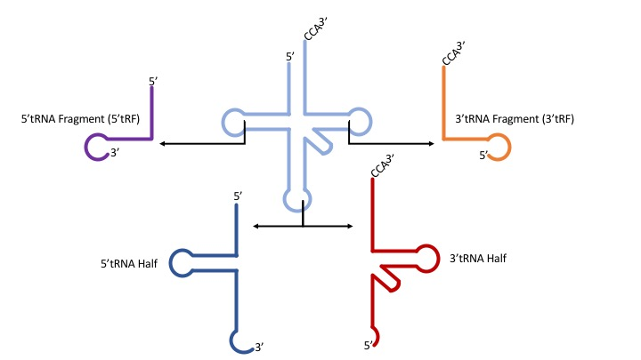

  **Figure 1: tRNA fragment processing** The mature tRNA secondary structure is centered (with the post-transcriptionally added CCA tail indicated) and surrounded by some of the predominant tRNA fragments that can occur by processing the mature tRNA at different positions (internal fragments and fragments occurring from precursor tRNA are not shown, but may also occur).
- Although there are nice visualizations of read-mapping available through Integrative Genomics Viewer (IGV) (or through a simpler tool, samtools tview), these tools don’t aggregate the data to give summary data of abundance (**Figure 2a**). This becomes very problematic when looking at very large datasets, especially when opening a file with IGV without downsampling regularly runs out of memory and personal computers crash when attempting to display the reads of a particular gene, if it is highly represented in the library. Instead, the downsampling option has to be used, which limits the view to a random sample of the reads, and has a coverage track at the top of the viewer to give scale of how prevalent sequences are in the library. This downsampled view can only allow vague conclusions to be made from data, and since it is an aggregate of many different sized reads, the coverage track cannot give reliable abundance estimates of any specific tRNA fragment. There are several tRF databases that use more transparent visualizations of tRNA fragments, tRFdb (tRNA fragment database) and MINTbase (mitochondrial nuclear tRF database). Both of these databases display tRF data as alignments to the tRNA gene, with abundance counts, giving greater clarity of which tRFs are more likely to be biologically relevant (**Figure 2b and c**). tRFdb only aligns and counts existing tRFs from various large-scale publicly available datasets, whereas MINTbase also includes theoretical fragments, giving unique names to every possible tRF (regardless of if it has been found in a dataset) (Kumar 2015, Pliatsika 2016, Pliatsika 2018). Notable datasets included in MINTbase are tRFs found in datasets from The Cancer Genome Atlas and tRFdb includes tRFs found in argonaut pulldown experiments. One caveat to both databases is that they both only allow for exact matches of the tRF to the tRNA gene, which simplifies the alignments, but might greatly underestimate fragment abundance because tRNA genes have many RNA modifications which can lead to variants introduced during reverse transcription (Qin 2016).

## a

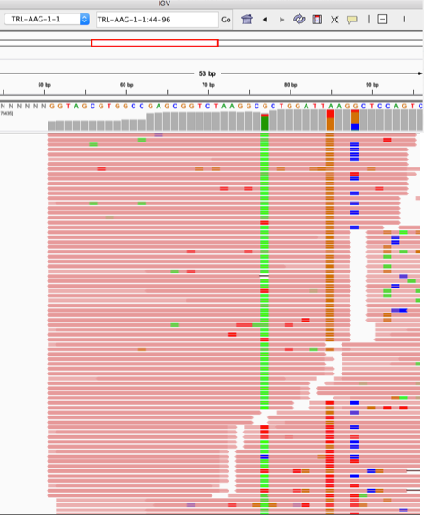

## b

[figure not shown]

## c

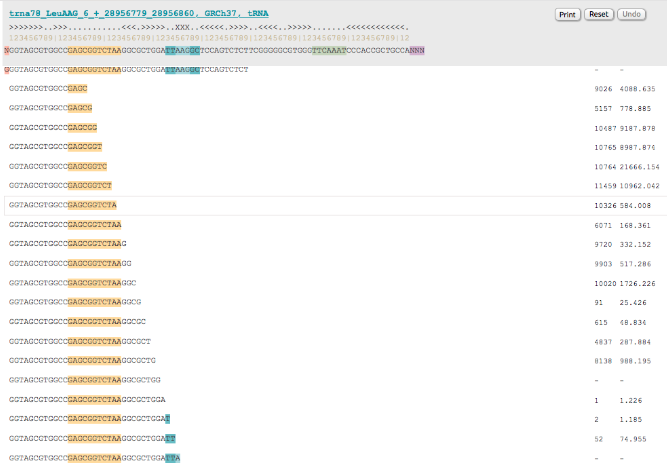

**Figure 2: tRNA fragment viewing options** Examples of the viewing output using **a)** IGV, **b)** tRFdb, **c)** and MINTbase.

- So, databases like tRFdb and MINTbase, both contain useful visual outputs for RNA fragment data that I can model a visualization of my own RNA sequencing libraries with. There is one important caveat to tRFdb’s and MINTbase’s methods that I don’t want to mirror, which is that both of these databases only count a tRF read if they are perfect matches. MINTbase even includes links to Modomics (an RNA modification database) (Boccaletto 2018, Dunin-Horkawicz 2006), so you can see just how decorated tRNA sequences are, so it’s not a stretch to assume that possibly a majority of the RNA-seq output will have the presence of modifications, and throwing out these reads could drastically reduce the fragments’ abundance in the data, and therefore it’s assumed importance (Qin 2016).
- Besides visualizing and counting predominant tRNA fragments, I also want to compare their expression to miRNAs in my RNA-seq libraries. But this is a comparison that is rife with problems, as RNA-seq can do a good job at identifying small RNAs, but not as good of a job at accurately quantifying them.

## Aims

#### 1) To make an alignment script so that I can count and align all the tRNA fragment reads from my RNA-seq libraries.

#### 2) Create a scoring method to estimate which miRNAs will be overrepresented versus underrepresented in TGIRT-seq libraries.

## Aim 1: tRNA read alignment visualization

In this first aim, I developed a visualization and counting tool for quantifying the most abundant tRNA fragments in my RNA-seq data sets. I wrote a script to visualize the alignment and count the reads in a similar way to several tRNA fragment databases, tRFdb and MINTbase, which align tRNA fragment reads from publicly available datasets and compare the read counts to indicate predominant fragments. With this visualization script, I can now compare my tRNA fragment datasets to other publicly available records more easily, and also have greater confidence in categorizing what the most abundant tRNA fragments in my datasets are.

### Python Script

In order to make a python script that could take a reference file and an alignment file to create a visualization of the alignment, it was first important to understand what information I can use from the alignment file (bam file). In my case, the important information contained in the bam file was  
1) the reference gene the read aligned to  
2) the position where the alignment starts  
3) and the sequence of the read.  
With these components, I have everything I need to align the reads to the reference.

**Click to View the Script**

```python
# This python script takes inputs of a reference sequence and an RNA-seq text file of a specified gene and gives the output of an alignment of the identified reads to it's reference sequence.

# This first input of this script is a fasta formatted reference sequence file and this file is used to generate a dictionary, including the sequence ID as the dictionary key and the sequence as the dictionary value.

refDict = dict()
with open('/Users/elizabethferrick/python/project/Pass1.fa', 'r') as reference:
    refLoS = reference.read().splitlines()
    for i in range(0,len(refLoS),2):
        #print(i)
        refDict[refLoS[i]] = refLoS[i+1]

# The second file input is the RNA sequencing library, which has already been pre-processed on the bash shell to extract the desired columns of data, sort and count them into a list of unique counted sequences, and select for a specified tRNA fragment.

# bash commands for pre-processing RNA-seq bam input file:
# samtools view Pass1_U5.sort.bam | grep 'TRL' | awk '{print $3" "$4" "$10}' | sort | uniq -c | sort -k3 -n | \
#    grep 'TRL-AAG-1-1:TRL-AAG-1-1:tRNA:37:38:63:86' > counted_TRL-AAG-1-1_Pass1_U5.sort.txt

with open('/Users/elizabethferrick/python/project/counted_TRL-AAG-1-1_Pass1_U5.sort.txt','r') as seq:
    seqLoS = seq.read().splitlines()
    seqLoL = []
    for record in seqLoS:
        seqLoL.append(record.split())

# align the sorted pre-processed input file to the reference sequence (called from the dictionary)

align = []
for record in seqLoL:
    record_string = ''
    spacedRead = ''
    if ('>'+record[1]) in refDict:
        spacedRead = ((int(record[2])-1) * '.') + record[3] + \
        ((len(refDict[('>' + record[1])])-(int(record[2]) - 1) - len(record[3])) * '.' + '\t' + record[0])
        align.append(spacedRead)
    record_string = str(('>'+record[1]) +'\n' + refDict[('>'+record[1])] + '\t' + 'reads' + '\n' + '\n'.join(align))

# write the aligned output to a file

with open('U5_TRL-AAG-1-1_align.txt','w') as outFile:
    outFile.write(record_string)
```

### Output

**Click for Full Output**

```bash
cat /Users/elizabethferrick/python/project/U5_TRL-AAG-1-1_align.txt
```

```
>TRL-AAG-1-1:TRL-AAG-1-1:tRNA:37:38:63:86
GGTAGCGTGGCCGAGCGGTCTAAGGCGCTGGATTAAGGCTCCAGTCTCTTCGGAGGCGTGGGTTCGAATCCCACCGCTGCCACCA   reads
GGTAGCGTGGCCGAGCGGTCTAAGGCACTGGATTGAGGCTCCAGTCTCTTCGGAGGCGTGGGTTCGGATCCCACC..........   10
TGGTAGCGTGGCCGAGCGGTCTAAGGCACTGGATTGAGCCTCCAGTCTCTTCGGAGGCGTGGGTTCGCATCCCAC..........   10
GGGTAGCGTGGCCGAGCGGTCTAAGGCACTGGATTGAGGCTCCAGTCTCTTCGGAGGCGTGGGTTCGGATCCCAC..........   11
TGGTAGCGTGGCCGAGCGGTCTAAGGCCCTGGATTGAGGCTCCAGTCTCTTCGGAGGCGTGGGTTCGGATCCCAC..........   11
CGGTAGCGTGGCCGAGCGGTCTAAGGCTCTGGATTGAGGCTCCAGTCTCTTCGGAGGCGTGGGTTCGGATCCCAC..........   12
TGGTAGCGTGGCCGAGCGGTCTAAGGCACTGGATTGAGGCTCCAGTCTCTTCGGAGGCGTGGGTTCGTATCCCAC..........   138
TGGTAGCGTGGCCGAGCGGTCTAAGGCACTGGATTGAGTCTCCAGTCTCTTCGGAGGCGTGGGTTCGAATCCCAC..........   13
GGTAGCGTGGCCGAGCGGTCTAAGGCTCTGGATTGAG................................................   14
TGGTAGCGTGGCCGAGCGGTCTAAGGCACTGGATTGAGACTCCAGTCTCTTCGGAGGCGTGGGTTCGGATCCCAC..........   14
GGTAGCGTGGCCGAGCGGTCTAAGGCACTGGATTGAGGCTCCAGTCTCTTCGG................................   15
GGTAGCGTGGCCGAGCGG...................................................................   16
TGGTAGCGTGGCCGAGCGGTCTAAGGCGCTGGATTGAGGCTCCAGTCTCTTCGGAGGCGTGGGTTCGTATCCCAC..........   16
CGGTAGCGTGGCCGAGCGGTCTAAGGCACTGGATTGAGTCTCCAGTCTCTTCGGAGGCGTGGGTTCGGATCCCAC..........   17
CGGTAGCGTGGCCGAGCGGTCTAAGGCACTGGATTGAGCCTCCAGTCTCTTCGGAGGCGTGGGTTCGGATCCCAC..........   18
CGGTAGCGTGGCCGAGCGGTCTAAGGCACTGGATTGAGCCTCCAGTCTCTTCGGAGGCGTGGGTTCGTATCCCAC..........   18
TGGTAGCGTGGCCGAGCGGTCTAAGGCACTGGATTGAGTCTCCAGTCTCTTCGGAGGCGTGGGTTCGTATCCCAC..........   18
TGGTAGCGTGGCCGAGCGGTCTAAGGCACTGGATTGAGCCTCCAGTCTCTTCGGAGGCGTGGGTTCGAATCCCAC..........   19
TTGGTAGCGTGGCCGAGCGGTCTAAGGCACTGGATTGAGGCTCCAGTCTCTTCGGAGGCGTGGGTTCGGATCCC...........   19
ACGGTAGCGTGGCCGAGCGGTCTAAGGCACTGGATTGAGGCTCCAGTCTCTTCGGAGGCGTGGGTTCGGATCC............   1
AGGTAGCGAGGCCGAGCGGTCTAAGGCAATTGAATGAGCCTCCAGTATCTACGGAGGCGTGGGTTCGGA................   1
AGGTAGCGTGGCCGAGAGGTCTAAGGCACTGGATTGAGTCTCCAGTCTATTCGGAGGCGTGGGTTCGAATCCCAC..........   1
AGGTAGCGTGGCCGAGCGGTCTAAGCCACTGGATTGAGCCTCCAGTCTCTTCGGAGGCGTGGGTTGGTATACC............   1
AGGTAGCGTGGCCGAGCGGTCTAAGGCACTGGATTGAGCCTCCAGTCTCTTCGGAGGCGTGGGTTCGTATCCCAC..........   1
AGGTAGCGTGGCCGAGCGGTCTAAGGCACTGGATTGAGGCTCCACTCTCTTCGGAGGCGTGGGTTCGCATCCCAC..........   1
AGGTAGCGTGGCCGAGCGGTCTAAGGCACTGGATTGAGGCTCCAGTCTCTTCGGAGGCGT.........................   1
AGGTAGCGTGGCCGAGCGGTCTAAGGCACTGGATTGAGGCTCCAGTCTCTTCGGAGGCGTGGGTTCGGATCCC............   1
AGGTAGCGTGGCCGAGCGGTCTAAGGCACTGGATTGAGGCTCCAGTCTCTTCGGAGGCGTGGGTTCGTATCCCAC..........   1
AGGTAGCGTGGCCGAGCGGTCTAAGGCACTGGATTGAGTCTCCACTCTCTTCGGAGGCGTGGGTTCGGATCCCAC..........   1
AGGTAGCGTGGCCGAGCGGTCTAAGGCACTGGATTGAGTCTCCAGTCTCTTCGGAGGCGTGGGTTCGTATCCCAC..........   1
AGGTAGCGTGGCCGAGCGGTCTAAGGCTCTGGATTGAGGCTCCAGTCTCTTCGGAGGCGTGGGTTCGTATCCCAC..........   1
ATGGTAGCGTGGCCGAGCGGTCTAAGGCACTGGATTGAGCCTCCAGTCTCTTCGGAGGCGTGGGTTCGTATCCCA..........   1
ATGGTAGCGTGGCCGAGCGGTCTAAGGCACTGGATTGAGGCTCCAGTCTCTTCGGAGGCGTGGGTTCGGATCCC...........   1
CCGGTAGCGTGGCCGAGCGGTCTAAGGCACTGGATTGAGGCTCCAGTCTCTTCGGAGGCGTGGGTTCGATCCCAC..........   1
CCGGTAGCGTGGCCGAGCGGTCTAAGGCACTGGATTGAGGCTCCAGTCTCTTCGGAGGCGTGGGTTCGGATCCCA..........   1
CGGTAGCGTGACCGAGCGGTCTAAGGCACTGGATTGAGCCTCCAGTCTCTTCGGAGGCGTGGGTACGGATCCCAC..........   1
CGGTAGCGTGGCAGAGCGGTCTAAGGCACTGGATTGAGGCTCCAGTCTCTTCGGAGGCGTGGGTTCGGATCCCAC..........   1
CGGTAGCGTGGCCGAGCGGTCTAAGGCACAGGATTGAGGCTCCAGTCTCTTCGGAGGCGTGGGTTCGGATCCCA...........   1
CGGTAGCGTGGCCGAGCGGTCTAAGGCACTGGACTGAGGCTCCAGTCTCTTCGGAGGCGTGGGTTCGGATCCCAC..........   1
```

[output cut: 1953 more lines]

```
...................................................................ATCCCACCGCTGCCACCA   44
...................................................................TTCCCACCGCTGCCACCA   5
....................................................................TCCCACCGCAGCCAC..   1
....................................................................TCCCACCGCTGCCACCC   1
....................................................................TCCCCCCGCTGCCACCA   1
....................................................................GCCCACCGCTGCCACC.   2
....................................................................GCTCCCACCGCTGCCACCA 2
....................................................................TCCTACCGCTGCCACCA   2
....................................................................TCCCACCGCTGCCACCA   46
....................................................................TTTCCCACCGCTGCCACCA 4
....................................................................TCCCACCGCTGCCAC..   5
....................................................................TCCCACCGCTGCCACC.   6
.....................................................................TCCACCGCTGCCACCA   4
.....................................................................CCCACCGCTGCCACCA   6
......................................................................CCACCGCTGCCACCA   4
```

**Click for Output of reads >=100**

```bash
cat /Users/elizabethferrick/python/project/U5_TRL-AAG-1-1_align.txt | grep \\d\\d\\d
```

```
TGGTAGCGTGGCCGAGCGGTCTAAGGCACTGGATTGAGGCTCCAGTCTCTTCGGAGGCGTGGGTTCGTATCCCAC..........   138
TGGTAGCGTGGCCGAGCGGTCTAAGGCACTGGATTGAGGCTCCAGTCTCTTCGGAGGCGTGGGTTCGGATCCCAC..........   244
............GAGCGGTCTAAGGCACTGGATTGAGCCTCCAGTCTCTTCGGAGGCGTGGGTTCGGATCCCACCGCTGCCACCA   133
............GAGCGGTCTAAGGCACTGGATTGAGGCTCCAGTCTCTTCGGAGGCGTGGGTTCGTATCCCACCGCTGCCACCA   198
............GAGCGGTCTAAGGCACTGGATTGAGGCTCCAGTCTCTTCGGAGGCGTGGGTTCGGATCCCACCGCTGCCACCA   421
..........................TCTGGATTGAGGCTCCAGTCTCTTCGGAGGCGTGGGTTCGGATCCCACCGCTGCCACCA   151
...........................CTGGATTGAGGCTCCAGTCTCTTCGGAGGCGTGGGTTCGGATCCCACCGCTGCCACCA   1000
...........................CTGGATTGAGGCTCCAGTCTCTTCGGAGGCGTGGGTTCGATCCCACCGCTGCCACCA.   126
...........................CTGGATTGAGCCTCCAGTCTCTTCGGAGGCGTGGGTTCGTATCCCACCGCTGCCACCA   128
...........................CTGGATTGAGGCTCCAGTCTCTTCGGAGGCGTGGGTTCGAATCCCACCGCTGCCACCA   141
...........................CTGGATTGAGTCTCCAGTCTCTTCGGAGGCGTGGGTTCGGATCCCACCGCTGCCACCA   169
...........................CTGGATTGAGGCTCCAGTCTCTTCGGAGGCGTGGGTTCGCATCCCACCGCTGCCACCA   170
...........................CTGGATTGAGCCTCCAGTCTCTTCGGAGGCGTGGGTTCGGATCCCACCGCTGCCACCA   256
...........................CTGGATTGAGGCTCCAGTCTCTTCGGAGGCGTGGGTTCGTATCCCACCGCTGCCACCA   476
..................................GAGGCTCCAGTCTCTTCGGAGGCGTGGGTTCGGATCCCACCGCTGCCACCA   142
.....................................TCTCCAGTCTCTTCGGAGGCGTGGGTTCGGATCCCACCGCTGCCACC.   128
.....................................TCTCCAGTCTCTTCGGAGGCGTGGGTTCGTATCCCACCGCTGCCACCA   182
.....................................TCTCCAGTCTCTTCGGAGGCGTGGGTTCGGATCCCACCGCTGCCACCA   433
......................................CTCCAGTCTCTTCGGAGGCGTGGGTTCGTATCCCACCGCTGCCACCA   121
......................................CTCCAGTCTCTTCGGAGGCGTGGGTTCGGATCCCACCGCTGCCACCA   220
.......................................TCCAGTCTCTTCGGAGGCGTGGGTTCGTATCCCACCGCTGCCACC.   102
.......................................TCCAGTCTCTTCGGAGGCGTGGGTTCGAATCCCACCGCTGCCACCA   112
.......................................TCCAGTCTCTTCGGAGGCGTGGGTTCGGATCCCACCGCTGCCACC.   148
.......................................TCCAGTCTCTTCGGAGGCGTGGGTTCGTATCCCACCGCTGCCACCA   274
.......................................TCCAGTCTCTTCGGAGGCGTGGGTTCGGATCCCACCGCTGCCACCA   834
............................................TCTCTTCGGAGGCGTGGGTTCGGATCCCACCGCTGCCACCA   151
.......................................................GCGTGGGTTCGTATCCCACCGCTGCCACCA   111
.......................................................GCGTGGGTTCGGATCCCACCGCTGCCACCA   216
..........................................................TGGGTTCGGATCCCACCGCTGCCACCA   114
```

### Conclusions

My script is sucessful! There are a few bugs where if a read has an insertion or deletion, it will extend past the reference in the alignment (but this is a minority case since insertions and deletions are rare).  
Additional processing on the bash shell with regular expressions allows filtering for just the most abundant reads.

### A few improvements can still be made:

1. Pass in arguments from the bash shell for the input and output file information (whereas right now I’m having to specify the files inside of the script).
2. Generalize the flow so that more than one output file can be made at a time (right now only one alignment is made at a time).
3. Add a way to identify the nucleotide variants that are likely RNA modifications.

## Aim 2: miRNA scoring in TGIRT-seq libraries

### Bash Script

This first bash script was used to process the raw data with Fastqc and extract the Per base sequence content.

**Click for fastqc_processing_Perbase.sh**

```bash
 #!/bin/bash

 # the purpose of this script is to take a deep seq file with extension .fq.gz, run it through fastqc, unzip only the text file, and extract the Per base sequence content from the txt file

# original file input:
## filename.fq.gz (can be entered as bash wildcard *.fq.gz)

# so final files created:
## filename_fastqc.zip
## filename_fastqc.html
## filename_fastqc_data.txt
## filename_fastqc_PerBaseSeqContent.txt

module load fastqc

# "$#" allows extended inputs from the shell
# so I can use bash wildcards to process many files at a time
for filenameExt in "$@"; do

# filename is the filename WITHOUT extensions, extracted using parameter expansions
   filename=${filenameExt%.fq.gz}

# first step runs the file through fastqc
# the output of the command below are filename_fastqc.html and filename_fastqc.zip
   fastqc ${filename}.fq.gz

# the next step is to unzip the fastqc_data.txt file inside filename_fastqc.zip
# the structure of the path to the txt file can be checked with less filename_fastqc.zip or unzip -l filename_fastqc.zip
# redirecting stdout to a file allows renaming the data file with the desired specific filename
   unzip -p ${filename}_fastqc.zip ${filename}_fastqc/fastqc_data.txt > ${filename}_fastqc_data.txt

# extract just the per base sequence content from the fastqc_data.txt file

   sed -n '/>>Per base sequence content/{:a;n;/>>END_MODULE/q;p;ba}' ${filename}_fastqc_data.txt > ${filename}_fastqc_PerBaseSeqContent.txt

done
```

```
## bash: line 13: module: command not found
```

### Python Scripts

This first python script was used to evaluate the scoring method that was calculated in the first part of the R script, iterating the score associated with each of the first and last 3 nucleotides of each miRNA sequence.

**Click for miRNA_scoring.py**

```python
# bring in the data and do processing steps to convert it into a list of lists
seqLoL = []
with open('/Users/elizabethferrick/Box Sync/lab/deep_seq/miRNA/MiR.info', 'r') as inFile:
    seqLoS = inFile.read().splitlines()
    for record in seqLoS:
        seqLoL.append(record.split())
seqLoL.pop(0)

scoreLoL = []
with open('/Users/elizabethferrick/Box Sync/lab/deep_seq/miRNA/scoring_PerBaseSeqContent.txt', 'r') as inFile2:
    scoreLoS = inFile2.read().splitlines()
    for record in scoreLoS:
        scoreLoL.append(record.split())
scoreLoL.pop(0)

# create the dictionary of the scores reading the info from scoreLoL
# line[0] = base = key
# line[1] = index = index in List of dictionaries
# line[2] = score = value
scoreDict = []
for i in range(0,6):
    scoreDict.append({'A':0, 'T':0, 'G':0, 'C':0})
for line in scoreLoL:
    scoreDict[int(line[1])][line[0]] += int(line[2])

# evaluate the scores stored in the dictionary for each of the miRxplore miRNAs

evalScoreList = []
for line in seqLoL:
    evalScore = 0
    for i in range(-3,3):
        evalScore += scoreDict[i][line[1][i]]
    evalScoreList.append(evalScore)

with open('miRxplore_scored_list.txt', 'w') as outFile:
    outFile.write('ID' + '\t' + 'Score' + '\n')
    for i in range(len(seqLoL)):
        outFile.write(seqLoL[i][0] + '\t' + str(evalScoreList[i]) + '\n')
```

This second python script was used to calculate the scores of a particular subset of tRNA fragments and miRNAs that I’m interested in.

**Click for tRF_v_miRNA_scoring.py**

```python
# bring in the data and do processing steps to convert it into a list of lists
seqLoL = []
with open('/Users/elizabethferrick/Box Sync/lab/deep_seq/miRNA/tRF_v_miR_seq.txt', 'r') as inFile:
    seqLoS = inFile.read().splitlines()
    for record in seqLoS:
        seqLoL.append(record.split())
seqLoL.pop(0)

scoreLoL = []
with open('/Users/elizabethferrick/Box Sync/lab/deep_seq/miRNA/scoring_PerBaseSeqContent.txt', 'r') as inFile2:
    scoreLoS = inFile2.read().splitlines()
    for record in scoreLoS:
        scoreLoL.append(record.split())
scoreLoL.pop(0)

# create the dictionary of the scores reading the info from scoreLoL
# line[0] = base = key
# line[1] = index = index in List of dictionaries
# line[2] = score = value
scoreDict = []
for i in range(0,6):
    scoreDict.append({'A':0, 'T':0, 'G':0, 'C':0})
for line in scoreLoL:
    scoreDict[int(line[1])][line[0]] += int(line[2])

# evaluate the scores stored in the dictionary for each of the miRxplore miRNAs

evalScoreList = []
for line in seqLoL:
    evalScore = 0
    for i in range(-3,3):
        evalScore += scoreDict[i][line[1][i]]
    evalScoreList.append(evalScore)

with open('tRF_v_miR_scored_list.txt', 'w') as outFile:
    outFile.write('ID' + '\t' + 'Score' + '\n')
    for i in range(len(seqLoL)):
        outFile.write(seqLoL[i][0] + '\t' + str(evalScoreList[i]) + '\n')
```

### R Script (and graphs)

I performed all my dataframe manipulations and data visualization using the R script below. Sometimes I would manipulate the data in R, to output to a text file, that would be read into python for the implementation of the scoring method.

```r
# this script is taking data from a miRxplore RNA-seq
# I ran fastqc on the raw data, and extracted the Per Base Sequence Content
# Below I'm Visualizing the data with goal to look like the rest of the labs' visualizations

library(readr)
library(tidyverse)

# this metadata links the sample number with it's metadata
metadata <- read_tsv("/Users/elizabethferrick/Box Sync/lab/deep_seq/miRNA/MiR_Peter_MDA.metadata")
metadata %>%
  filter(name %in% c(14, 38, 39))
```

```
## # A tibble: 3 x 10
##    name counts newname Enzyme  Temp adapter Sample `DTS/STS` comment `miR(pmol)`
##   <dbl>  <dbl> <chr>   <chr>  <dbl> <chr>   <chr>  <chr>     <chr>         <dbl>
## 1    14 1.45e7 NTT60-1 G         60 NTT     MiR    STS       <NA>              1
## 2    38 1.42e7 G-NTT1  G         60 NTT     MiR    STS       <NA>              2
## 3    39 1.48e7 G-NTT2  G         60 NTT     MiR    STS       <NA>              2
```

[figure not shown]

```r
# read in the data I processed with bash script: fastqc_processing_Perbase.sh
NTT60.1_14_1_fastqc_PerBaseSeqContent <- read_tsv("/Users/elizabethferrick/Box Sync/lab/deep_seq/miRNA/fastqc_PerBaseSeqContent/14.1_fastqc_PerBaseSeqContent.txt") %>%
  mutate("Sample" = "NTT60.1", "Read" = "Read 1")
NTT60.1_14_2_fastqc_PerBaseSeqContent <- read_tsv("/Users/elizabethferrick/Box Sync/lab/deep_seq/miRNA/fastqc_PerBaseSeqContent/14.2_fastqc_PerBaseSeqContent.txt") %>%
  mutate("Sample" = "NTT60.1", "Read" = "Read 2")
G.NTT1_38_1_fastqc_PerBaseSeqContent <- read_tsv("/Users/elizabethferrick/Box Sync/lab/deep_seq/miRNA/fastqc_PerBaseSeqContent/38.1_fastqc_PerBaseSeqContent.txt") %>%
  mutate("Sample" = "G.NTT1", "Read" = "Read 1")
G.NTT1_38_2_fastqc_PerBaseSeqContent <- read_tsv("/Users/elizabethferrick/Box Sync/lab/deep_seq/miRNA/fastqc_PerBaseSeqContent/38.2_fastqc_PerBaseSeqContent.txt") %>%
  mutate("Sample" = "G.NTT1", "Read" = "Read 2")
G.NTT2_39_1_fastqc_PerBaseSeqContent <- read_tsv("/Users/elizabethferrick/Box Sync/lab/deep_seq/miRNA/fastqc_PerBaseSeqContent/39.1_fastqc_PerBaseSeqContent.txt") %>%
  mutate("Sample" = "G.NTT2", "Read" = "Read 1")
G.NTT2_39_2_fastqc_PerBaseSeqContent <- read_tsv("/Users/elizabethferrick/Box Sync/lab/deep_seq/miRNA/fastqc_PerBaseSeqContent/39.2_fastqc_PerBaseSeqContent.txt") %>%
  mutate("Sample" = "G.NTT2", "Read" = "Read 2")

# now that all the tibbles have unique identifiers, can join them together with rbind
miRxplore_fastqc_PerBaseSeqContent = rbind(NTT60.1_14_1_fastqc_PerBaseSeqContent,
                                           NTT60.1_14_2_fastqc_PerBaseSeqContent,
                                           G.NTT1_38_1_fastqc_PerBaseSeqContent,
                                           G.NTT1_38_2_fastqc_PerBaseSeqContent,
                                           G.NTT2_39_1_fastqc_PerBaseSeqContent,
                                           G.NTT2_39_2_fastqc_PerBaseSeqContent) %>%
  mutate("Base Position" = case_when(Read == "Read 1" ~ `#Base`,
                                     Read == "Read 2" ~ -`#Base`)) %>%
  mutate(`U`=`T`) %>%
  pivot_longer(cols=c(`G`,`A`,`U`,`C`), names_to = "Base_no_Rev_comp", values_to = "Frequency") %>%
  select(`Base Position`, Base_no_Rev_comp, Frequency, Sample, Read) %>%
  mutate(Base = case_when(Read == "Read 1" ~ Base_no_Rev_comp,
                          Read == "Read 2" & Base_no_Rev_comp == "A" ~ "U",
                          Read == "Read 2" & Base_no_Rev_comp == "U" ~ "A",
                          Read == "Read 2" & Base_no_Rev_comp == "G" ~ "C",
                          Read == "Read 2" & Base_no_Rev_comp == "C" ~ "G")) %>%
  mutate(Fraction = case_when(Read == "Read 1" ~ Frequency/100,
                              Read == "Read 2" ~ Frequency/100))

# This graph shows the biased sequence output of the miRNA library, with the nucleotide frequencies showing which nucleotides are overrepresented vs underrepresented at each nucleotide position (showing just the first and last 10 positions).
miRxplore_fastqc_PerBaseSeqContent %>%
  filter(`Base Position` < 11 & Read == "Read 1" | `Base Position` > -11 & Read == "Read 2" ) %>%
  ggplot(aes(x= `Base Position`, y= Fraction, color= Base))+
  geom_point()+
  geom_smooth(span = 0.14)+ #0.14 was the lowest I could go when added facet_grid
  scale_color_manual(breaks = c("U","C","A","G"), values = c("orange", "blue", "black", "red"))+
  facet_grid(. ~ Read, scales = "free")+
  scale_x_continuous(breaks = -10:10)+
  theme_bw()+
  theme(panel.grid.minor = element_blank())
```

[figure not shown]

```r
# now I have a good idea that the 3 datasets are very consistent with each other and I can calculate the mean at each nucleotide position
mean_miRxplore_fastqc_PerBaseSeqContent = miRxplore_fastqc_PerBaseSeqContent %>%
  select(`Base Position`, Read, Base, Sample, Fraction) %>%
  pivot_wider(names_from = Sample, values_from = Fraction) %>%
  mutate("Avg_Fraction" = rowMeans(select(., NTT60.1, G.NTT1, G.NTT2))) #rowmeans is base fxn so need to pass the data in as .

miRxplore_expected <- read_tsv("/Users/elizabethferrick/Box Sync/lab/deep_seq/miRNA/miRxplore_nt_freq.txt")

# because I processed the data in python, the indeces for the positive bases are off by 1, so make a column with the nucleotide positions
miRxplore_expected_reindex = miRxplore_expected %>%
  mutate(`Expected Frequency` = frequency) %>%
  mutate(`Base Position` = case_when(python_nt_index >= 0 ~ python_nt_index+1,
                              python_nt_index < 0 ~ python_nt_index)) %>%
  mutate(Base = case_when(base == 'T' ~ 'U',
                          base %in% c("A", "C", "G") ~ base)) %>%
  mutate(Read = case_when(`Base Position` > 0 ~ "Read 1",
                          `Base Position` < 0 ~ "Read 2"))

# here is the expected nucleotide frequency of the input miRNA sample (each miRNA is added at an equivalent amount)
miRxplore_expected_reindex %>%
  ggplot(aes(x = `Base Position`, y = `Expected Frequency`, color = Base))+
  geom_line()+
  scale_color_manual(breaks = c("U","C","A","G"), values = c("orange", "blue", "black", "red"))+
  facet_grid(. ~ Read, scales = "free")
```

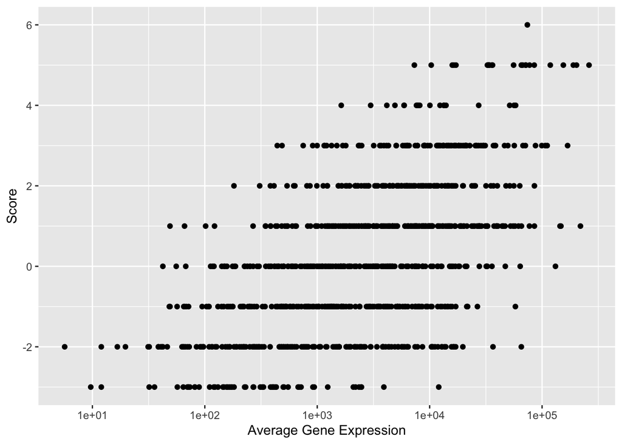

```r
# use the average values to create a scoring system
# divide by the frequency in the expected nucleotide frequency calculated above and subtract 1, to make 25% centered at zero
# round to integer to create an integer score
scoring = mean_miRxplore_fastqc_PerBaseSeqContent %>%
  filter(`Base Position` %in% c(1,2,3,-3,-2,-1)) %>%
  full_join(miRxplore_expected_reindex) %>%
  mutate("Normalized_Avg" = (Avg_Fraction/`Expected Frequency`)-1) %>%
  mutate("Score" = round(Normalized_Avg, digits = 0))

# since I'm going to evaluate the scoring in python, I'm going to output the file with python-compatible indeces
output = scoring %>%
  select(base, python_nt_index, Score) %>%
  write_tsv("/Users/elizabethferrick/Box Sync/lab/deep_seq/miRNA/scoring_PerBaseSeqContent.txt")

# input the scored miRxplore list that I evaluated in python with miRNA_scoring.py
miRxplore_scored_list <- read_tsv("/Users/elizabethferrick/Box Sync/lab/deep_seq/miRNA/miRxplore_scored_list.txt")

miRxplore_counts <- read_tsv("/Users/elizabethferrick/Box Sync/lab/deep_seq/miRNA/MiR_Peter_MDA.counts")

miRxplore_counts_NTT = miRxplore_counts%>%
  select(ID, G.NTT1, G.NTT2, NTT60.1) %>%
  full_join(miRxplore_scored_list) %>%
  mutate(`Average Gene Expression` = rowMeans(select(., NTT60.1, G.NTT1, G.NTT2)))

# This graph shows the comparison of the predictive score versus the observed average gene expression from the 3 replicate libraries.
graph = miRxplore_counts_NTT %>%
  ggplot(aes(x = `Average Gene Expression`, y = Score, label = ID))+
  geom_point()+
  scale_x_log10()
graph
```

```r
# look for correlations between the score and gene expression
miR_correlation = lm(`Average Gene Expression` ~ Score, data = miRxplore_counts_NTT)
summary(miR_correlation)
```

```
##
## Call:
## lm(formula = `Average Gene Expression` ~ Score, data = miRxplore_counts_NTT)
##
## Residuals:
##    Min     1Q Median     3Q    Max
## -26124  -8960  -3560   2653 229270
##
## Coefficients:
##             Estimate Std. Error t value Pr(>|t|)
## (Intercept)   9212.7      676.6   13.62   <2e-16 ***
## Score         4636.7      347.6   13.34   <2e-16 ***
## ---
## Signif. codes:  0 '***' 0.001 '**' 0.01 '*' 0.05 '.' 0.1 ' ' 1
##
## Residual standard error: 20820 on 960 degrees of freedom
## Multiple R-squared:  0.1564, Adjusted R-squared:  0.1555
## F-statistic: 177.9 on 1 and 960 DF,  p-value: < 2.2e-16
```

### Many improvements can be made:

1. Make the scoring wider range to differentiate the ranks more (multiple the fraction by a number before rounding).
2. Score based on first and last 4nt or 5nt, instead of just 3.
3. Add additional sequences to compare against (like full length tRNAs).
4. Perhaps figure a way to classify miRNAs into groups of overexpressing and underexpressing and look for motif similarities?

## References

Boccaletto, P. et al. MODOMICS: a database of RNA modification pathways. 2017 update. Nucleic Acids Res 46, D303–D307 (2018).  
Dunin-Horkawicz, S. et al. MODOMICS: a database of RNA modification pathways. Nucleic Acids Res 34, D145–D149 (2006).  
Kim, H. K. et al. A transfer-RNA-derived small RNA regulates ribosome biogenesis. Nature 552, 57–62 (2017).  
Kumar, P., Mudunuri, S. B., Anaya, J. & Dutta, A. tRFdb: a database for transfer RNA fragments. Nucleic Acids Res 43, D141–D145 (2015).  
Kuscu, C. et al. tRNA fragments (tRFs) guide Ago to regulate gene expression post-transcriptionally in a Dicer-independent manner. RNA 24, 1093–1105 (2018).  
Pliatsika, V. et al. MINTbase v2.0: a comprehensive database for tRNA-derived fragments that includes nuclear and mitochondrial fragments from all The Cancer Genome Atlas projects. Nucleic Acids Res 46, D152–D159 (2018).  
Pliatsika, V., Loher, P., Telonis, A. G. & Rigoutsos, I. MINTbase: a framework for the interactive exploration of mitochondrial and nuclear tRNA fragments. Bioinformatics 32, 2481–2489 (2016).  
Qin, Y. et al. High-throughput sequencing of human plasma RNA by using thermostable group II intron reverse transcriptases. RNA 22, 111–128 (2016).  
Schorn, A. J., Gutbrod, M. J., LeBlanc, C. & Martienssen, R. LTR-Retrotransposon Control by tRNA-Derived Small RNAs. Cell 170, 61-71.e11 (2017).  
Zheng, G. et al. Efficient and quantitative high-throughput transfer RNA sequencing. Nat Methods 12, 835–837 (2015).